# Chicago Crime Analysis

Evan Munson

2022-11-20

The data for this analysis was acquired from the Chicago Data Portal[^1]. The dataset contains incidents of crime (with the exception of murders where data exists for each victim) that occurred in the City of Chicago from 2001 to present, with the exception of events in the last seven days. The dataset contains 7,672,798 events specifically from, 2001-01-01 to 2022-11-08. If any questions arise concerning the data, please direct them to the Data Fulfillment and Analysis Division (DFA) of the Chicago Police Department.

The Analysis Team began the investigation into crime across the city by first gaining a better understanding of what types of crime typically happened across the city. As seen in Figure 1 the top five offenses seen across the city include: Theft, Battery, Criminal Damage, Narcotics, and Assault.

In addition to understanding what crimes occurred it is also useful to understand where crimes are generally being observed across the City of Chicago. In Figure 2 we can easily observed that the top five locations where crime is committed is: Street, Residence, Apartment, Sidewalk, and Other locations.

### 0.0.1 Appendix

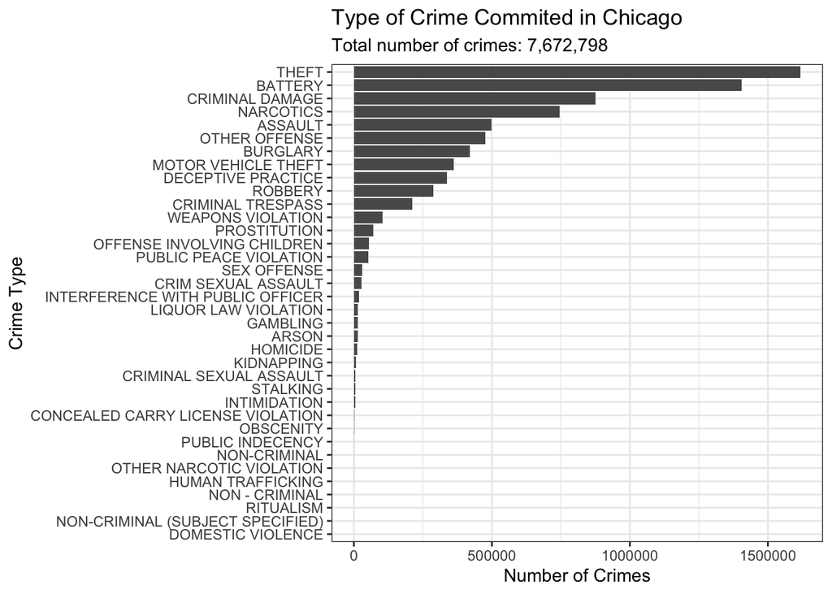

Figure 1: Types of Crime

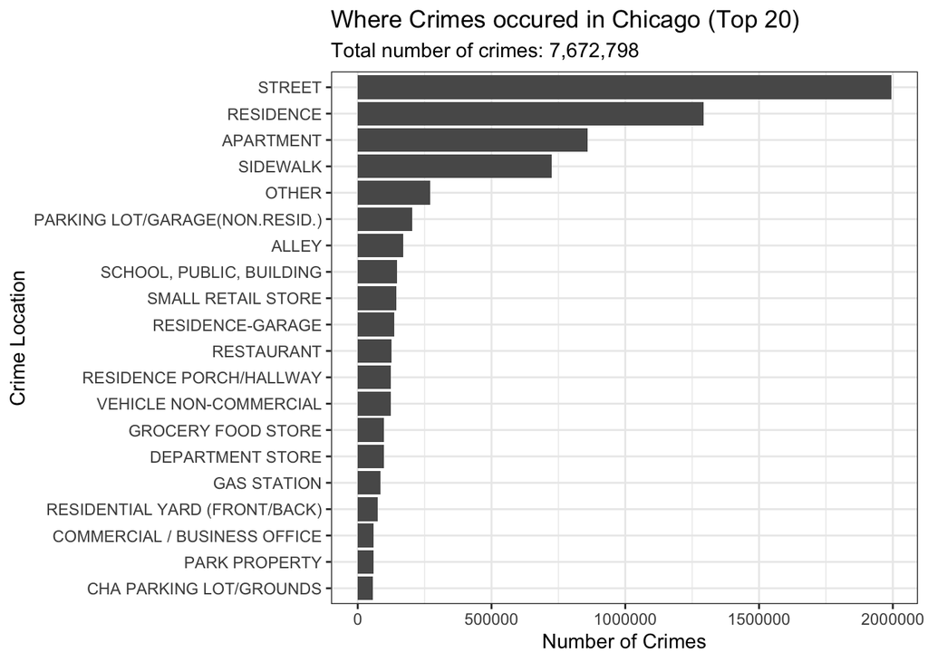

Figure 2: Where Crimes occured in Chicago

[^1]: https://data.cityofchicago.org/Public-Safety/Crimes-2001-to-Present/ijzp-q8t2